# STSCI 5065 - Lecture 17

Install and Configure Ipython Notebook with Apache Spark in HDP

Harry Lu

# 1 Required Components

- HDP 2.5 (containing Apache Spark) on Hortonworks sandbox
  - Go to http://hortonworks.com/downloads/ and download for Virtualbox
  - Install HDP in Virtualbox
- Python 2.7X

# 2 Configure the Dependencies

- At Centos prompt, **type** the following commands:

  ```
  yum install nano centos-release-SCL zlib-devel
  yum install bzip2-devel openssl-devel ncurses-devel
  yum install sqlite-devel readline-devel tk-devel
  yum install gdbm-devel db4-devel libpcap-devel xz-devel
  yum install libpng-devel libjpg-devel atlas-devel
  ```

# 3 Install the “Development tools” Dependency for Python 2.7

- Ipython requires Python 2.7 or higher (the version came with the HDP installation is Python 2.6.
- Execute:

  ```
  yum groupinstall "Development tools"
  ```

# 4 Install Python 2.7

- Run the following command to get Python 2.7:

  ```
  yum install python27
  ```

  (if it does not work, first run `yum install centos-release-scl`)
- Get the Python Anaconda distribution to upgrade Python to current version and to obtain the most useful Python packages for scientific computation.

  ```
  yum install wget
  wget https://repo.continuum.io/archive/Anaconda2-4.3.1-Linux-x86_64.sh
  bash Anaconda2-4.3.1-Linux-x86_64.sh
  ```

  (accept the license and type ‘yes’)

# 5 Install or Upgrade Python Analytics Packages

- By installing the latest version of Anaconda, you should have all the following Python packages for data science: `numpy`, `scipy`, `matplotlib`, `pandas`, `scikitlearn`, `tornado`, `pyzmq`, `pygments`, `jsonschema` and `jinja2`. Use pip to check installation or to upgrade them if already installed:

  ```
  pip install numpy scipy pandas matplotlib scikit-learn
  pip install tornado pyzmq pygments jsonschema
  pip install jinja2 --upgrade
  pip install matplotlib --upgrade
  pip install scikit-learn --upgrade
  pip install numpy --upgrade
  ...
  ```

# 6 Install and Configure IPython Notebook

- Run the following command to install ipython notebook if not already installed:

  ```
  pip install "ipython[notebook]"
  ```

- Configure a Pyhton interpreter built with Apache Spark by creating an Ipython profile for pyspark:

  ```
  ipython profile create pyspark
  ```

- Generate a Jupyter configuration file:

  ```
  jupyter notebook --generate-config
  ```

- You should see the following output:

  ```
  Writing default config to: /root/.jupyter/jupyter_notebook_config.py
  ```

# 7 Create a Shell Script to Start IPython

- In a text editor (vi), in the home directory (~) create a shell script `called start_ipython_notebook.sh`.

  ```
  #!/bin/bash
  source /opt/rh/python27/enable
  IPYTHON_OPTS = "notebook --port 8889 --notebook-dir='/usr/hdp/2.5.0.0-1245/spark/' --ip='*' --no-browser" pyspark
  ```

- Make the above shell script executable:

  ```
  chmod +x start_ipython_notebook.sh
  ```

# 8 Port Forwarding

- In order for IPython notebook to be accessible from a browser on your host machine, if not already completed, you must forward the port 8889 from the virtual machine to the host machine:
1. Open the VirtualBox
2. Click the **Setting** button
3. Select the **Network** tab

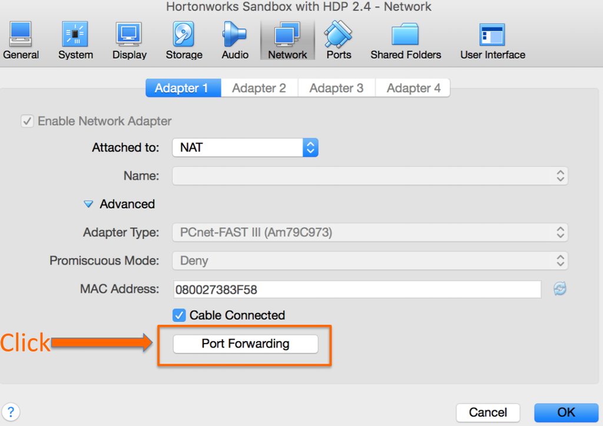

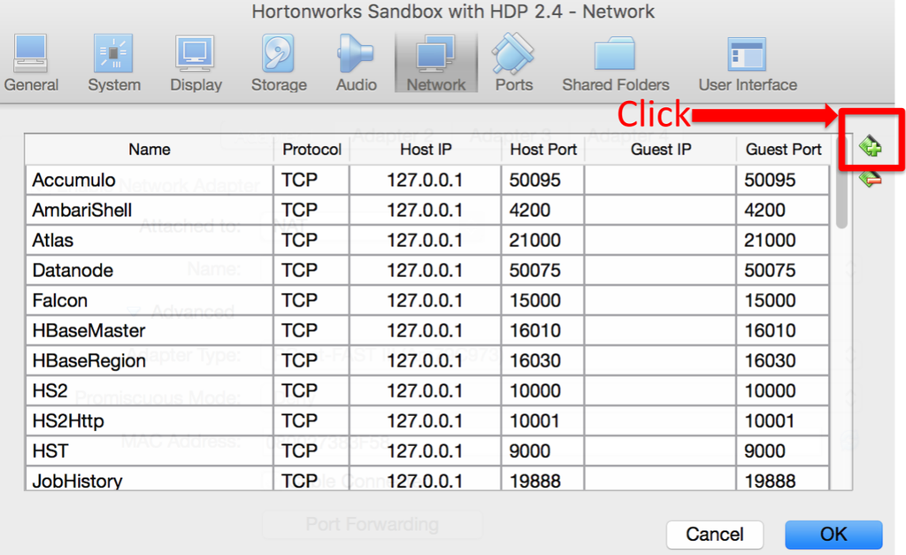

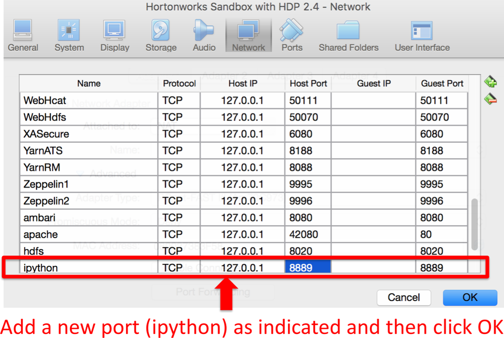

# 9 Running IPython Notebook

- Execute the shell script from CentOS (home director ~):

  ```
  ./start_ipython_notebook.sh
  ```

  Copy the URL created by the script or record the token for login in next step.

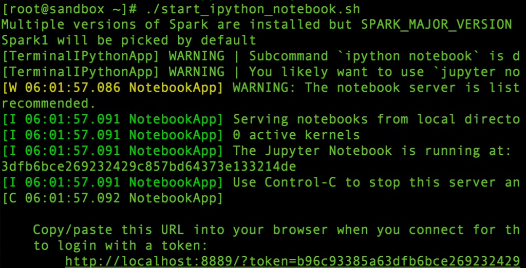

- Open a browser on your host machine, paste in the URL from last step to enter, or enter http://127.0.0.1:8889 to the URL window and you should see a login window. Enter the token to enter.

[figure not shown]

# 10 Jupyter (IPython) Notebook

- After log in:

[figure not shown]